# High School Seniors 2

# Loading in the data

This Highschool data records different measurements and survey data from highschool seniors.

```r
library(mosaic)
library(DT)
library(pander)
library(car)
library(tidyverse)
library(ggpubr)

# Read in the data
HighSchoolSeniors <- read.csv("https://raw.githubusercontent.com/ajaverett/data/main/HighSchoolSeniors.csv", header = TRUE)


# View(HighSchoolSeniors)
```

# Wrangling the data

Below wrangles the data to create 1 quantitative column and 2 categorical columns based on the following:

- **Quantitative**: how smart a student is as measured as an intelligence score
- **Qualitative**: sleep categories by severity
  1. At recommended
  2. Lower than recommended
  3. Much lower than recommended
- **Qualitative**: Video game categories by usage
  1. 0 - 1 hours per week
  2. less than 1 hour a school day
  3. more than 1 hour a school day

```r
HighSchoolSeniors2 <- HighSchoolSeniors %>%

  # Creating IQ column

  filter(Score_in_memory_game %in% seq(20,80)) %>%
  filter(Reaction_time %in% seq(0,1.5,.0001)) %>%
  mutate(memory = Score_in_memory_game,
         reaction = Reaction_time,
         z.reaction = zscore(reaction, na.rm = TRUE),
         z.memory = zscore(memory, na.rm = TRUE)) %>%
  rowwise() %>%
  mutate(z.avg = mean(c(z.reaction, z.memory)),
         iq = z.avg*15 + 100) %>%

  # Creating Video Game column

  filter(Video_Games_Hours < 20) %>%
  mutate(
    v.hours = case_when(
      Video_Games_Hours %in% 0:1  ~ "0 - 1 hours per week",
      Video_Games_Hours %in% 2:7  ~ "less than 1 hour a school day",
      Video_Games_Hours %in% 8:20 ~ "more than 1 hour a school day",
    )) %>%

  # Sleep groups

  mutate(
    s.hours = case_when(
      Sleep_Hours_Schoolnight %in% 0:5 ~ "Much lower than recommended",
      Sleep_Hours_Schoolnight %in% 5:7  ~ "Lower than reccomended",
      Sleep_Hours_Schoolnight %in% 8:20 ~ "At recommended"
    )) %>%

  na.omit()

View(HighSchoolSeniors2 %>% select(iq, v.hours, s.hours))
```

# Hypothesis

Where s refers to sleep category, v refers to video game usage category, an i refers to any level of a factor, the three hypotheses are as following:

$$H_{0}: \mu_{s1} = \mu_{s2} = \mu_{s3}\\
H_a: \mu_{si} \neq \mu \ \text{for at least one}\ i\in\{1,2,3\}\\
-\\
H_{0}: \mu_{v1} = \mu_{v2} = \mu_{v3}\\
H_a: \mu_{si} \neq \mu \ \text{for at least one}\ i\in\{1,2,3\}\\
-\\
H_0: \text{The effect of s on IQ is the same for all levels of v.}\\
H_a: \text{The effect of s on IQ is not the same for all levels of v.}$$

# Two-way ANOVA

```r
myaov <- aov(iq~ s.hours*v.hours, data = HighSchoolSeniors2)

myaov %>% pander()
```

Analysis of Variance Model

|  | Df | Sum Sq | Mean Sq | F value | Pr(>F) |
| --- | --- | --- | --- | --- | --- |
| **s.hours** | 2 | 760.2 | 380.1 | 3.08 | 0.04868 |
| **v.hours** | 2 | 639.6 | 319.8 | 2.591 | 0.07806 |
| **s.hours:v.hours** | 4 | 751.9 | 188 | 1.523 | 0.1979 |
| **Residuals** | 162 | 19996 | 123.4 | NA | NA |

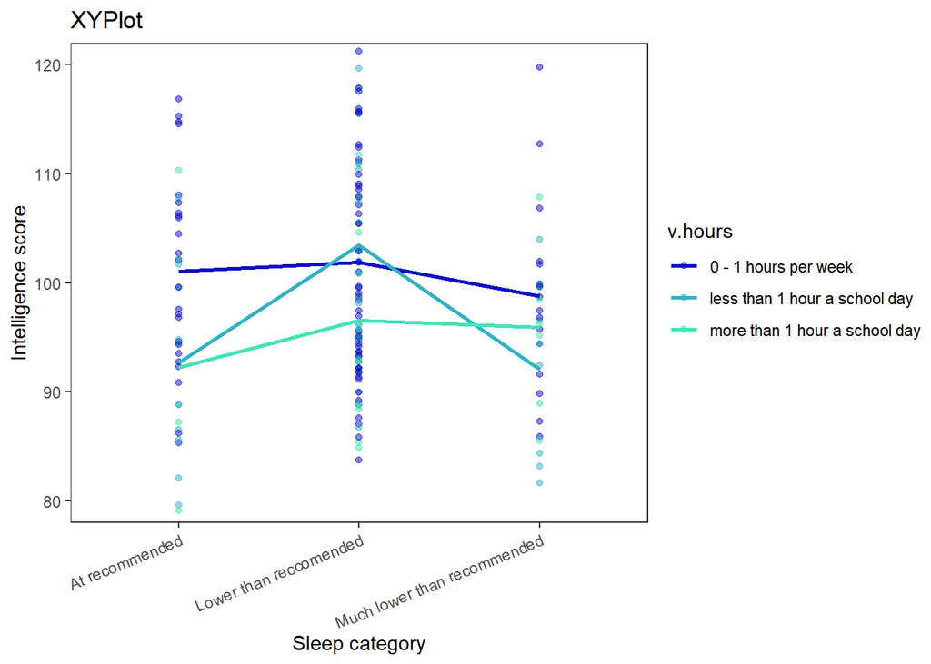

```r
# View(HighSchoolSeniors2 %>% select(iq, vg.hours, ssn.hours))

ggplot(HighSchoolSeniors2, aes(x = s.hours, y = iq, group = v.hours, color = v.hours)) +
  geom_point(alpha = .5) +
  stat_summary(fun = "mean", geom = "line", size = 1) +
  labs(
    title = "XYPlot",
    x = "Sleep category",
    y = "Intelligence score"
  ) +
  theme_test() +
  theme(axis.text.x = element_text(angle = 22.5, vjust = 1, hjust=1)) +
  scale_fill_manual('legend_title') +
  scale_color_manual(values = c("#0C0EC6", "#32B1C3", "#43E2B7")) +
  coord_cartesian(ylim = c(80, 120))
```

# Testing assumption

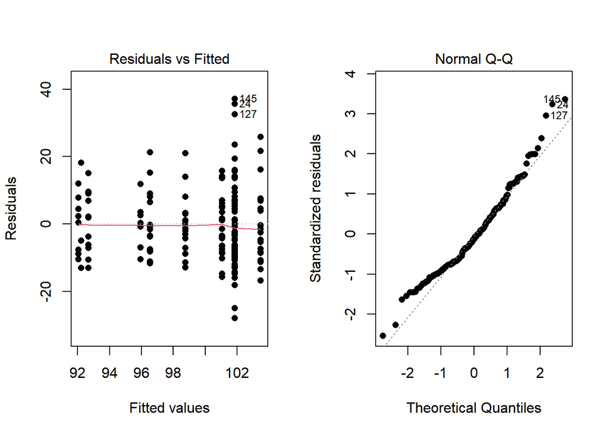

```r
par(mfrow=c(1,2))
plot(myaov, which=1:2, pch=16)
```

From the QQ Plot, we can discover that the data seems to be slightly right skewed. From the analysis, intelligence data seems to be significantly non-normal. Though, this may because the cut-off point was arbitrary

```r
pander(shapiro.test(HighSchoolSeniors2$iq))
```

Shapiro-Wilk normality test: `HighSchoolSeniors2$iq`

| Test statistic | P value |
| --- | --- |
| 0.9663 | 0.000364 * * * |

# Conclusion

From the analysis, we can see if the evidence disproves any assumptions from our hypotheses. From the first hypothesis which assumes the means within the sleep factor are equal, we can say that with 95 percent confidence that there is enough evidence to reject the hypothesis that the means within the sleep factor associate with different intelligence scores. Additionally, there is not enough evidence to reject the null hypothesis that the means are different for video game usage categories. Finally, there is also not enough evidence to reject the hypothesis that the effect of sleep categories on intelligence scores is the same for all levels of video game groups.